## Анализ главных компонент данных car2004

#### Загрузка данных

```r
data_car <- read_excel("C:/Users/redmi/OneDrive/Документы/R analysis/car2004.xls", na = "*")
colnames(data_car) <- gsub("-", "_", colnames(data_car))

# Добавление доп.столбцов
data_car$Other <- ifelse(rowSums(data_car[c("Sport", "SportUtil", "Wagon", "Minivan", "Pickup")]) == 0, 1, 0)
data_car$Front_wheel <- ifelse(rowSums(data_car[c("All_wheel", "Rear_wheel")]) == 0, 1, 0)

# Создание категориальных переменных
data_car <- data_car %>%
mutate(
  Body_type = factor(case_when(
    Sport == 1 ~ 1,
    SportUtil == 1 ~ 2,
    Wagon == 1 ~ 3,
    Minivan == 1 ~ 4,
    Pickup == 1 ~ 5,
    Other == 1 ~ 6,
    TRUE ~ NA_integer_
  ), levels = c(1, 2, 3, 4, 5, 6), labels = c("Sport", "SportUtil", "Wagon", "Minivan", "Pickup", "Other"))
)

data_car <- data_car %>%
  mutate(
    Wheel_type = factor(case_when(
      All_wheel == 1 ~ 1,
      Rear_wheel == 1 ~ 2,
      Front_wheel == 1 ~ 3,
      TRUE ~ NA_integer_
    ), levels = c(1, 2, 3), labels = c("All_wheel", "Rear_wheel", "Front_wheel"))
  )

head(data_car, 5) |>
 print_df()
```

| Name | Sport | SportUtil | Wagon | Minivan | Pickup | All_wheel | Rear_wheel | Retail | Dealer | Engine | Cylinders | Horsepower | CityMPG | HW_MPG | Weight | WheelBase | Length | Width | Other | Front_wheel | Body_type | Wheel_type |
| --- | --- | --- | --- | --- | --- | --- | --- | --- | --- | --- | --- | --- | --- | --- | --- | --- | --- | --- | --- | --- | --- | --- |
| Chevrolet Aveo 4dr | 0 | 0 | 0 | 0 | 0 | 0 | 0 | 11690 | 10965 | 1.6 | 4 | 103 | 28 | 34 | 2370 | 98 | 167 | 66 | 1 | 1 | Other | Front_wheel |
| Chevrolet Aveo LS 4dr hatch | 0 | 0 | 0 | 0 | 0 | 0 | 0 | 12585 | 11802 | 1.6 | 4 | 103 | 28 | 34 | 2348 | 98 | 153 | 66 | 1 | 1 | Other | Front_wheel |
| Chevrolet Cavalier 2dr | 0 | 0 | 0 | 0 | 0 | 0 | 0 | 14610 | 13697 | 2.2 | 4 | 140 | 26 | 37 | 2617 | 104 | 183 | 69 | 1 | 1 | Other | Front_wheel |
| Chevrolet Cavalier 4dr | 0 | 0 | 0 | 0 | 0 | 0 | 0 | 14810 | 13884 | 2.2 | 4 | 140 | 26 | 37 | 2676 | 104 | 183 | 68 | 1 | 1 | Other | Front_wheel |
| Chevrolet Cavalier LS 2dr | 0 | 0 | 0 | 0 | 0 | 0 | 0 | 16385 | 15357 | 2.2 | 4 | 140 | 26 | 37 | 2617 | 104 | 183 | 69 | 1 | 1 | Other | Front_wheel |

1. *Name* - Название автомобиля - **качественный признак**
2. *Sport* - Спортивная машина (1=да, 0=нет) - **качественный признак** Легкие, обычно имеют мощные двигатели, способные развивать высокие скорости, чаще всего имеют задний или полный привод.
3. *SportUtil* - Внедорожник (тип кузова) (1=да, 0=нет) - **качественный признак** Характеризуется высокой посадкой, вместительным салоном, большим клиренсом и возможностью полного привода.
4. *Wagon* - Универсал (тип кузова) (1=да, 0=нет) - **качественный признак** Характеризуется увеличенным багажным отсеком, обычно имеет передний или полный привод.
5. *Minivan* - Минивэн (тип кузова) (1=да, 0=нет) - **качественный признак** Характеризуется большим количеством места для пассажиров и багажа, наиболее характерен передний привод. Некоторые модели минивэнов предлагают неплохую экономию топлива, учитывая их размер и вместительность.
6. *Pickup* - Пикап (тип кузова) (1=да, 0=нет) - **качественный признак** Характеризуется мощными двигателями и возможностью заднего или полного приводов.
7. *All-wheel* - Полный привод (1=да, 0=нет) - **качественный признак**
8. *Rear-wheel* - Задний привод (1=да, 0=нет) - **качественный признак**
9. *Retail* - Рекомендованная розничная цена в долларах (цена продажи диллером) - **количественный непрерывный**
10. *Dealer* - Закупочная цена для дилера в долларах - **количественный непрерывный**
11. *Engine* - Объем двигателя в литрах - **количественный дискретный**
12. *Cylinders* - Число цилиндров (=-1 для роторного двигателя) - **количественный дискретный**
13. *Horsepower* - Лошадиные силы - **количественный дискретный**
14. *CityMPG* - Ожидаемый пробег в милях на галлон топлива для автомобиля в условиях городского движения. - **количественный дискретный**
15. *HW_MPG* - Ожидаемый пробег в милях на галлон топлива для автомобиля в условиях движения по шоссе или трассе при постоянной скорости - **количественный дискретный**

В городском цикле обычно встречаются частые остановки, старты и пробки, что приводит к более частому использованию тормозов и ускорителей. Это может уменьшить экономию топлива.

В условиях шоссейного движения меньше остановок и меньше стартов, что может способствовать более высокой экономии топлива.

То есть ожидается, что HW_MPG > CityMPG.

16. *Weight* - Вес автомобиля в фунтах - **количественный непрерывный**
17. *WheelBase* - Расстояние между передними и задними колесами в дюймах - **количественный дискретный**
18. *Length* - Длина автомобиля в дюймах - **количественный дискретный**
19. *Width* - Ширина автомобиля в дюймах - **количественный дискретный**

Были добавлены еще два столбца, которые соответствуют другому (то есть ни одному из представленных) типу кузова (*Other*) и переднему приводу (*Front_wheel*).

Также были добавлены две категориальные переменные, отвечающие типу кузова (*Body_type*) и типу привода (*Wheel_type*).

#### Симметричность и выбросы

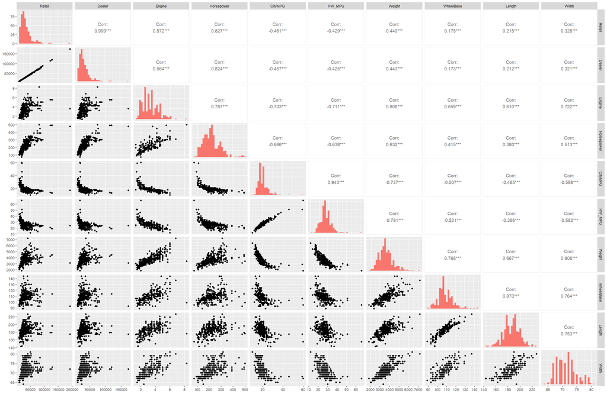

```r
data_select <- data_car %>% dplyr::select(-Name, -Sport, -SportUtil,-Wagon, -Minivan, -Pickup, -All_wheel, -Rear_wheel, -Front_wheel, -Other, -Cylinders, -Body_type, -Wheel_type)

create_ggpairs(data_select, density_diag = FALSE)
```

Наблюдения Retail, Dealer, Engine, Horsepower, CityMPG, HW_MPG, Weight, WheelBase имеют хвост вправо, прологарифмируем их и построим графики зависимостей признаков.

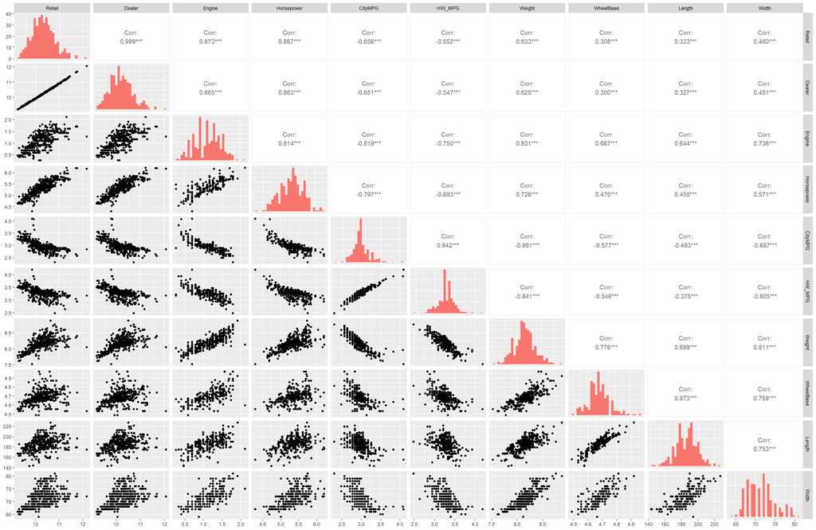

```r
data_log <- data_car %>%
  mutate_at(vars(Retail, Dealer, Engine, Horsepower, CityMPG, HW_MPG, Weight, WheelBase), ~log(.))

data_select <- data_log %>% dplyr::select(-Name, -Sport, -SportUtil,-Wagon, -Minivan, -Pickup, -All_wheel, -Rear_wheel, -Cylinders, -Other, -Front_wheel, -Body_type, -Wheel_type)

create_ggpairs(data_select, density_diag = FALSE)
```

Так как пропусков не так много, то заполним их медианным значением по каждому признаку.

```r
cols_to_fill <- c("CityMPG", "HW_MPG", "Weight", "WheelBase", "Length", "Width")
filled_cols <- na.aggregate(data_log[, cols_to_fill], FUN = median, na.rm = TRUE)
data_log[, cols_to_fill] <- filled_cols
```

## Результат PCA()

```r
library("FactoMineR")

data_pca <- data_log %>% dplyr::select(Retail, HW_MPG, WheelBase, Width, Length, Weight, Horsepower, Engine, CityMPG,   Cylinders, Body_type, Wheel_type)

res_car_pca <- PCA(data_pca, ncp = 9, quali.sup = c(10:12), graph = FALSE)
```

### Собственные числа

```r
datatable(res_car_pca$eig)
```

|  | eigenvalue | percentage of variance | cumulative percentage of variance |
| --- | --- | --- | --- |
| comp 1 | 6.189221258830123 | 68.76912509811253 | 68.76912509811253 |
| comp 2 | 1.212902328978563 | 13.47669254420626 | 82.24581764231878 |
| comp 3 | 0.6490117989186751 | 7.211242210207505 | 89.4570598525263 |
| comp 4 | 0.3476383804835108 | 3.862648672039011 | 93.3197085245653 |
| comp 5 | 0.1996869096552183 | 2.218743440613538 | 95.53845196517884 |
| comp 6 | 0.1814955673139104 | 2.016617414599005 | 97.55506937977785 |
| comp 7 | 0.1162776197197781 | 1.291973552441979 | 98.84704293221982 |
| comp 8 | 0.06930626445148887 | 0.7700696050165434 | 99.61711253723637 |
| comp 9 | 0.03445987164872642 | 0.3828874627636271 | 100 |

### Собственные вектора (U)

$$U_i=\frac{F_i}{\sqrt{\lambda_i}}, \
\text{где} \ F_i -\text{вектор i-x факторных нагрузок.}$$

```r
car_eigenvalues <- res_car_pca$eig[, 1]
car_factor_loadings <- res_car_pca$var$coord
car_eigenvectors <- sweep(car_factor_loadings, 2, sqrt(car_eigenvalues), FUN = "/")

print_df(car_eigenvectors)
```

| Dim.1 | Dim.2 | Dim.3 | Dim.4 | Dim.5 | Dim.6 | Dim.7 | Dim.8 | Dim.9 |
| --- | --- | --- | --- | --- | --- | --- | --- | --- |
| 0.2931204049384575 | -0.4416895129952721 | 0.5128986236234758 | 0.0805738118525605 | 0.3852027480601912 | -0.2094175975627372 | 0.2668278793929656 | -0.4263218361740717 | 0.06518705811091355 |
| -0.3340062881233874 | 0.2263724117501358 | 0.5870092838723049 | 0.1086063247346314 | 4.393540418859421e-05 | 0.1383254506138202 | -0.01364623465400608 | 0.08301831531558293 | -0.6742461753335481 |
| 0.3016816100646336 | 0.4533800223566805 | -0.1328061843205889 | 0.6292897079159895 | 0.3010972204650968 | 0.1252881152720088 | -0.3136345804451343 | -0.2912645380905 | -0.01527786613348735 |
| 0.3234030491834087 | 0.3088211392214633 | 0.1366781594213222 | -0.7308650245109283 | 0.2582212982797541 | 0.3013973950818051 | -0.2594419429564253 | -0.1494112194388493 | -0.006550230994547906 |
| 0.2846435338257703 | 0.5372222879826747 | 0.2884806203193117 | -0.04418274763105889 | -0.3393644402559712 | -0.6015262373855832 | 0.1721631102784323 | 0.1002536871372072 | 0.1688316100703258 |
| 0.3795282003193702 | 0.06176120938917314 | -0.1401219776701535 | 0.05980898345020379 | 0.387301049797553 | 0.138125078533985 | 0.5042965989965577 | 0.6088948018070736 | -0.1865047858048367 |
| 0.3417751052663475 | -0.3362508203649144 | 0.325529642105458 | 0.1421975851003588 | -0.1424956117773866 | 0.02670235428371801 | -0.6035254536072627 | 0.4980366886415717 | 0.1031209515151915 |
| 0.3681544739737418 | -0.04467423085605282 | 0.09542805714103468 | 0.1128940224109989 | -0.6154574818433282 | 0.5687739597679884 | 0.3071005721326601 | -0.2094776511295455 | -0.01146930733056242 |
| -0.359871318886692 | 0.2127424024895585 | 0.3716253513570399 | 0.1142316214309594 | 0.1732565383533639 | 0.3540390562286841 | 0.142936910509923 | 0.1774085586209408 | 0.6832370016649891 |

### Координаты признаков (Матрица факторных нагрузок F)

```r
print_df(res_car_pca$var$coord)
```

| Dim.1 | Dim.2 | Dim.3 | Dim.4 | Dim.5 | Dim.6 | Dim.7 | Dim.8 | Dim.9 |
| --- | --- | --- | --- | --- | --- | --- | --- | --- |
| 0.7292292097003549 | -0.4864408099671926 | 0.4131976375284115 | 0.04750701782076514 | 0.1721330145991319 | -0.08921670598592558 | 0.09098698435165464 | -0.1122338403081112 | 0.01210091497764742 |
| -0.830945704971666 | 0.2493081137000905 | 0.4729021255501362 | 0.06403523038052691 | 1.963312465629738e-05 | 0.05892981870392616 | -0.004653298380018499 | 0.02185547056982823 | -0.1251628141867204 |
| 0.7505279004194632 | 0.4993157836203556 | -0.1069903467916392 | 0.3710346659916521 | 0.1345493315067884 | 0.05337561443662786 | -0.1069478374149666 | -0.07667854395831929 | -0.002836086862620013 |
| 0.804566812809286 | 0.3401104184682957 | 0.1101096590504421 | -0.4309243530335873 | 0.1153896505942119 | 0.1284022121105733 | -0.08846841663488283 | -0.03933412159515334 | -0.001215943634304074 |
| 0.7081403263674645 | 0.591652817669497 | 0.2324036472286886 | -0.02605053094571175 | -0.1516495519390203 | -0.2562639916044896 | 0.05870676728561101 | 0.02639286885568396 | 0.03134083694226867 |
| 0.9441957806929219 | 0.0680187594133446 | -0.1128840427180008 | 0.03526389502100223 | 0.1730706688744702 | 0.0588444555962289 | 0.1719626407325939 | 0.1602981507204589 | -0.03462157399569513 |
| 0.8502730813331201 | -0.3703192323975162 | 0.2622508091622182 | 0.08384092863564624 | -0.06367607538084434 | 0.01137581616343776 | -0.2057991883311312 | 0.131113551870131 | 0.01914272407532561 |
| 0.9159000587485145 | -0.04920055469488201 | 0.07687805337833824 | 0.06656329409301424 | -0.2750254307394725 | 0.2423107691600244 | 0.1047197729659548 | -0.05514726023883999 | -0.002129089989357999 |
| -0.8952931049636934 | 0.2342971330236112 | 0.2993860972789836 | 0.06735195406847355 | 0.07742200800995978 | 0.1508287687123644 | 0.04874077802299953 | 0.04670472433747185 | 0.1268318145706685 |

### Координаты индивидов (Матрица главных компонент Z)

$$Z_i=XU_i=\sqrt{\lambda_i}V_i.$$

```r
print_df(res_car_pca$ind$coord)
```

| Dim.1 | Dim.2 | Dim.3 | Dim.4 | Dim.5 | Dim.6 | Dim.7 | Dim.8 | Dim.9 |
| --- | --- | --- | --- | --- | --- | --- | --- | --- |
| -4.994554184394814 | 0.2705129584324993 | -0.6291117853285991 | -0.0381306886433015 | -0.08152782589770335 | -0.004233308149316383 | 0.06358259101238434 | -0.1358230623315925 | 0.1062255332486576 |
| -5.27647905998924 | -0.3829213675848124 | -0.8583023293996601 | 0.01938517288125102 | 0.328047357348528 | 0.6111780122066142 | -0.1057957385757966 | -0.3370256921498131 | -0.05883628221007048 |
| -3.144870202646721 | 1.080412690980222 | 0.4265411949290754 | 0.05473690534261162 | -0.4167503328853122 | 0.07980529182378196 | -0.1854786211429127 | -0.0375568576716705 | -0.1940517854557129 |
| -3.194240214856904 | 0.9805171651873238 | 0.3840057128994318 | 0.2864775557229148 | -0.4428137658392546 | -0.003056102893811442 | -0.04422614252925119 | 0.06206301469701188 | -0.210431847896915 |
| -3.075724658199058 | 0.9762204841657671 | 0.5475312521867788 | 0.07374383899480928 | -0.3258830534717464 | 0.03040479442940933 | -0.1225353436241826 | -0.1381239112630924 | -0.1786745051706097 |
| -3.865539721551708 | 0.7808760997253495 | 0.0863984809398401 | 0.5846648893782208 | -0.09527802120778384 | 0.3503869584349322 | -0.1607350610899421 | 0.009389377317351491 | 0.1147100463401507 |
| -3.776070021752027 | 0.6992726574529474 | 0.175413482063053 | 0.6055200632701582 | 0.01293823836645193 | 0.3208370130500651 | -0.06595368762176433 | -0.023246122967886 | 0.1118563666528393 |
| -3.762582093596361 | 0.2532545891813491 | -0.509407336518307 | 0.3281668351239121 | -0.09772429739586286 | 0.3789027126401471 | -0.1840814315731799 | -0.04838466757636928 | -0.03185567000846422 |
| -4.127575221130983 | 0.5278374667334841 | -0.3185541381309991 | 0.3277219479255973 | 0.02767600224976776 | 0.4706798491938483 | 0.1551298645804791 | -0.271674657059583 | -0.2506978783750869 |
| -3.674706997789125 | 0.1137595839700373 | -0.3466586649111568 | 0.3528196106772571 | 0.01900165701319499 | 0.3115480072015636 | -0.1058630928813071 | -0.1891636113032818 | -0.009286146254994717 |

[output cut: 418 more lines]

## Визуализация

#### Scree plot

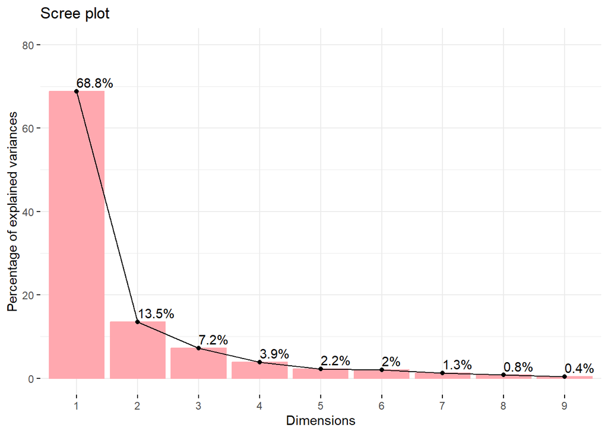

```r
fviz_eig(res_car_pca, addlabels = TRUE, ylim = c(0, 80), barfill = '#ffa8af', barcolor = '#ffa8af')
```

Имеет смысл рассматривать первые две компоненты, так как они объясняют ~82% дисперсии.

#### Factor map

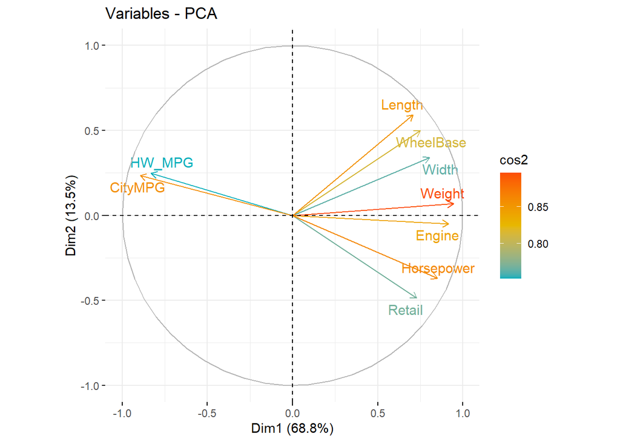

```r
fviz_pca_var(res_car_pca, col.var = "cos2",
             gradient.cols = c("#00AFBB", "#E7B800", "#FC4E07"),
             repel = TRUE
             )
```

Данный график показывает признаки и их корреляция с главными компонентами и корреляции признаков между собой.

Чем длинее стрелка, тем лучше признак представлен в пространстве первых двух главных компонент. В данном случае лучше всего представлены Weight, Horsepower, CityMPG, Length, Engine.

**Интерпретация первых двух главных компонент**:

1. Соответствует общему размеру (габаритам и массе) машины: чем машина больше, тем правее она будет расположена на плоскости первых двух главных компонент.
2. Дороговизна машины при фиксированном общем размере: чем дешевле машина при фиксированной первой координате, тем выше она будет расположена на плоскости первых двух главных компонент.

#### Biplot

**Группировка по Cylinders**

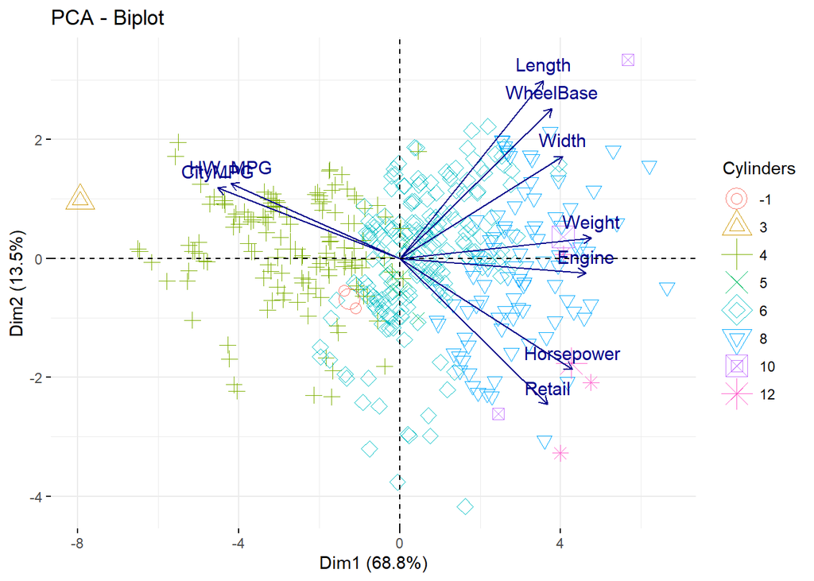

```r
fviz_pca_biplot(res_car_pca,
                geom.ind = "point",
                pointsize = 3,
                col.var = 'darkblue',
                habillage = 10)
```

Логично, что чем больше у машины двигателей, тем она больше.

**Группировка по Body_type**

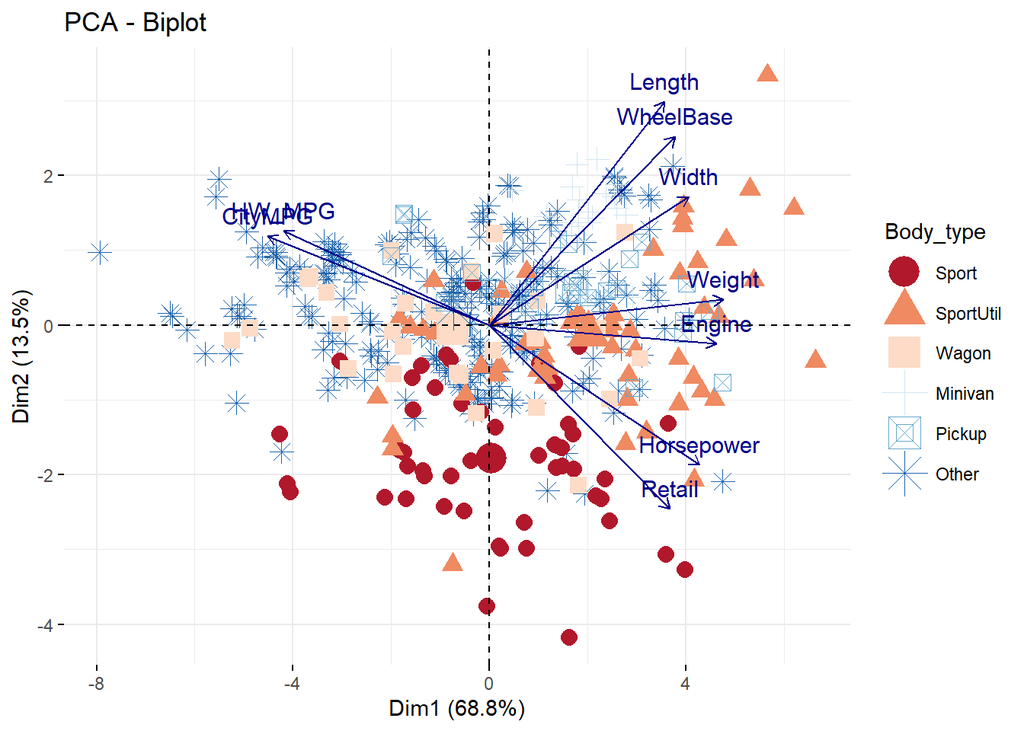

```r
fviz_pca_biplot(res_car_pca,
                geom.ind = "point",
                pointsize = 3.5,
                col.var = 'darkblue',
                habillage = 11)+
  ggpubr::color_palette("RdBu")
```

Спортивные машины более дорогие при фиксированной первой координате (общем размере машины), поэтому большинство их располагается внизу графика. Машины типы Other – можно сказать машины среднего ценового сегмента, расположение их в пространстве первых двух главных компонент подтверждает это. Минивэны являются более доступными машинами среди машин аналогичных размеров.

**Группировка по Wheel_type**

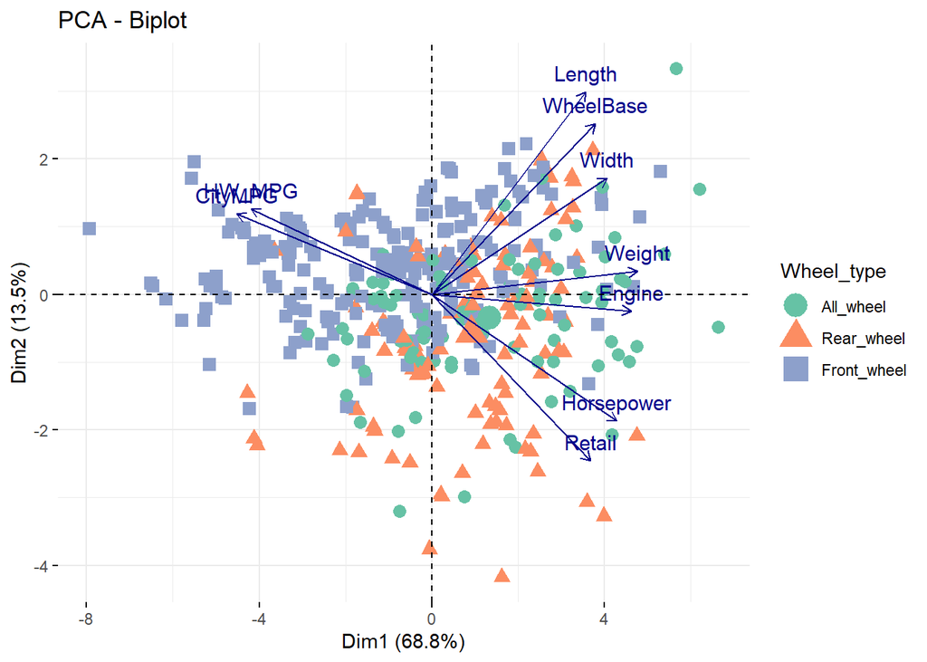

```r
fviz_pca_biplot(res_car_pca,
                geom.ind = "point",
                pointsize = 3,
                col.var = 'darkblue',
                habillage = 12)+
  ggpubr::color_palette("Set2")
```

При фиксированном общем размере машины, в основном заднеприводные автомобили более дорогие, а переднеприводные – более дешевые.

**Выделяющиеся наблюдения**

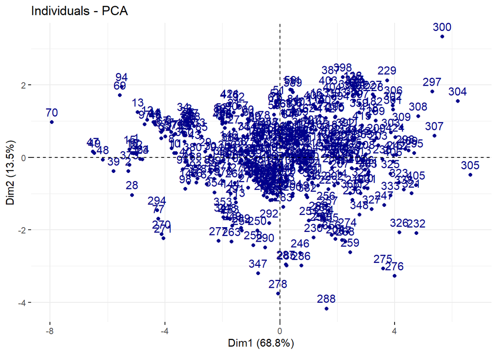

```r
fviz_pca_ind(res_car_pca, col.ind  = 'darkblue')
```

```r
selected_rows <- data_car[c(69, 94, 70, 300, 297, 305, 304, 288, 278, 275, 276), ]
print_df(selected_rows)
```

| Name | Sport | SportUtil | Wagon | Minivan | Pickup | All_wheel | Rear_wheel | Retail | Dealer | Engine | Cylinders | Horsepower | CityMPG | HW_MPG | Weight | WheelBase | Length | Width | Other | Front_wheel | Body_type | Wheel_type |
| --- | --- | --- | --- | --- | --- | --- | --- | --- | --- | --- | --- | --- | --- | --- | --- | --- | --- | --- | --- | --- | --- | --- |
| Honda Civic Hybrid 4dr manual (gas/electric) | 0 | 0 | 0 | 0 | 0 | 0 | 0 | 20140 | 18451 | 1.4 | 4 | 93 | 46 | 51 | 2732 | 103 | 175 | 68 | 1 | 1 | Other | Front_wheel |
| Toyota Prius 4dr (gas/electric) | 0 | 0 | 0 | 0 | 0 | 0 | 0 | 20510 | 18926 | 1.5 | 4 | 110 | 59 | 51 | 2890 | 106 | 175 | 68 | 1 | 1 | Other | Front_wheel |
| Honda Insight 2dr (gas/electric) | 0 | 0 | 0 | 0 | 0 | 0 | 0 | 19110 | 17911 | 2 | 3 | 73 | 60 | 66 | 1850 | 95 | 155 | 67 | 1 | 1 | Other | Front_wheel |
| Ford Excursion 6.8 XLT | 0 | 1 | 0 | 0 | 0 | 1 | 0 | 41475 | 36494 | 6.8 | 10 | 310 |  |  | 7190 | 137 | 227 | 80 | 0 | 0 | SportUtil | All_wheel |
| Chevrolet Suburban 1500 LT | 0 | 1 | 0 | 0 | 0 | 0 | 0 | 42735 | 37422 | 5.3 | 8 | 295 | 14 | 18 | 4947 | 130 | 219 | 79 | 0 | 1 | SportUtil | Front_wheel |
| Hummer H2 | 0 | 1 | 0 | 0 | 0 | 1 | 0 | 49995 | 45815 | 6 | 8 | 316 | 10 | 12 | 6400 | 123 | 190 | 81 | 0 | 0 | SportUtil | All_wheel |
| GMC Yukon XL 2500 SLT | 0 | 1 | 0 | 0 | 0 | 1 | 0 | 46265 | 40534 | 6 | 8 | 325 | 13 | 17 | 6133 | 130 | 219 | 79 | 0 | 0 | SportUtil | All_wheel |
| Porsche 911 GT2 2dr | 1 | 0 | 0 | 0 | 0 | 0 | 1 | 192465 | 173560 | 3.6 | 6 | 477 | 17 | 24 | 3131 | 93 | 175 | 72 | 0 | 0 | Sport | Rear_wheel |
| Mercedes-Benz SLK32 AMG 2dr | 1 | 0 | 0 | 0 | 0 | 0 | 1 | 56170 | 52289 | 3.2 | 6 | 349 | 17 | 22 | 3220 | 95 | 158 | 68 | 0 | 0 | Sport | Rear_wheel |
| Mercedes-Benz SL55 AMG 2dr | 1 | 0 | 0 | 0 | 0 | 0 | 1 | 121770 | 113388 | 5.5 | 8 | 493 | 14 | 21 | 4235 |  | 179 | 72 | 0 | 0 | Sport | Rear_wheel |

[output cut: 1 more lines]

- 69, 94, 70

Honda Civic Hybrid 4dr manual (gas/electric), Toyota Prius 4dr (gas/electric), Honda Insight 2dr (gas/electric) – гибридные автомобили, имеют примерно одинакаовые габариты. Все три автомобиля относятся к классу компактных автомобилей, который обычно считается более доступным, чем среднеразмерные или полноразмерные автомобили.

- 300

Ford Excursion 6.8 XLT – один из самых больших внедорожников, которые когда-либо выпускались. Более доступный по сравнению с современными моделями аналогичных габаритов.

- 297, 305, 304

Chevrolet Suburban 1500 LT, Hummer H2, GMC Yukon XL 2500 SLT – внедорожники, не такие дорогие, как некоторые другие автомобили премиум-класса аналогичных размеров.

- 288

Porsche 911 GT2 2dr – спортивный автомобиль, среднеразмерный. Самый дорогой автомобиль в выборке.

- 278

Mercedes-Benz SLK32 AMG 2dr – спортивный автомобиль, среднеразмерный. Среди автомобилей аналогичных размеров, является более дорогим.

- 275, 276

Mercedes-Benz SL55 AMG 2dr, Mercedes-Benz SL600 convertible 2dr – спортивные автомобили, имеют практически идентичные габариты, среднеразмерные. Среди машин аналогичных габаритов являются более дорогими.